# Markov Modelling in Health Economics — A Deep Dive

School of Public Health, AIIMS Bhopal

Teaching Resource — SPH Faculty

2026-09-23

# 1 Part 1 — The Basics: States, Transitions, and Time

## 1.1 Why Markov Models?

> “A Markov model is NOT primarily a complicated mathematical formula.  
> Think: I have a group of patients. At every time interval, some stay where they are,  
> some move to another health state, and some die.  
> I repeat that process over time and attach costs and health outcomes to the states.”

### 1.1.1 The Clinical Problem

Imagine we are evaluating whether **Treatment A** is worth its cost compared to **Treatment B** for a chronic disease.  
We need to answer:

- How many patients stay well? How many become sick? How many die — and when?
- What does each year of health *cost* the system?
- What is the *quality* of life in each health state?

A Markov model lets us track all of this over time.

## 1.2 Health States

We start with **three health states**:

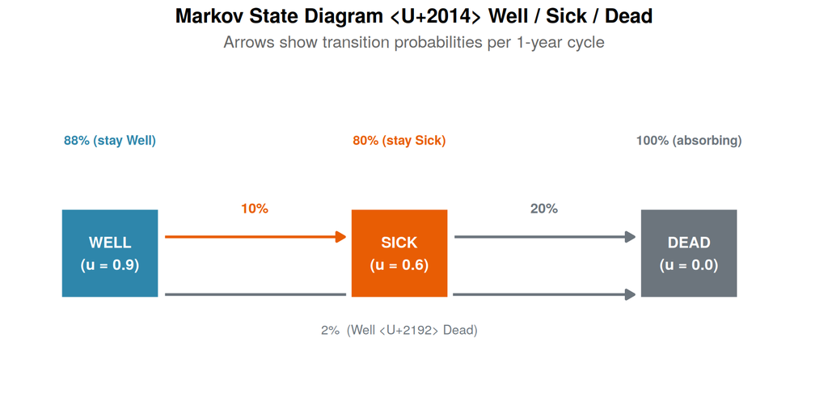

### 1.2.1 Key Properties of States

Properties of Markov Health States

| Property | Meaning | Our Example |
| --- | --- | --- |
| Mutually exclusive | A patient is in ONE state at a time | Cannot be Well AND Sick simultaneously |
| Exhaustive | Every patient must be in some state | Well + Sick + Dead = 100% |
| Absorbing state | Once entered, impossible to leave | Dead → Dead = 100%; no resurrection |

## 1.3 Transition Probabilities

Transition Probability Matrix Each ROW must sum to 1.0

|  | TO: Well | TO: Sick | TO: Dead |
| --- | --- | --- | --- |
| FROM: Well | 0.88 (stay Well) | 0.10 (→ Sick) | 0.02 (→ Dead) |
| FROM: Sick | 0.00 (no recovery) | 0.80 (stay Sick) | 0.20 (→ Dead) |
| FROM: Dead | 0.00 | 0.00 | 1.00 (absorbing) |

> **Rule:** Every row in the transition matrix must sum to exactly 1.0.  
> Every patient must *go somewhere* at the end of each cycle.

# 2 Part 2 — Building the Cohort Trace

## 2.1 Setup in R

```r
# ── Transition probability matrix ──────────────────────────────────────────
P <- matrix(
  c(0.88, 0.10, 0.02,   # from Well
    0.00, 0.80, 0.20,   # from Sick
    0.00, 0.00, 1.00),  # from Dead (absorbing)
  nrow = 3, byrow = TRUE,
  dimnames = list(
    c("Well","Sick","Dead"),
    c("Well","Sick","Dead")
  )
)

# ── Verify rows sum to 1 ────────────────────────────────────────────────────
cat("Row sums (must all equal 1):\n")
```

```
## Row sums (must all equal 1):
```

```r
print(rowSums(P))
```

```
## Well Sick Dead
##    1    1    1
```

```r
# ── Starting population ─────────────────────────────────────────────────────
n_start <- 1000
state_0  <- c(Well = n_start, Sick = 0, Dead = 0)

# ── Parameters ─────────────────────────────────────────────────────────────
n_cycles <- 30          # 30-year horizon
cycle_len <- 1          # 1 year per cycle
utilities  <- c(Well = 0.90, Sick = 0.60, Dead = 0.00)
costs      <- c(Well = 5000, Sick = 30000, Dead = 0)    # rupees per person per year
```

## 2.2 Running the Model

```r
# ── Pre-allocate trace matrix ────────────────────────────────────────────────
trace <- matrix(0, nrow = n_cycles + 1, ncol = 3,
                dimnames = list(paste0("Cycle ", 0:n_cycles), c("Well","Sick","Dead")))
trace[1, ] <- state_0

# ── Iterate through cycles ────────────────────────────────────────────────────
for (t in 1:n_cycles) {
  trace[t + 1, ] <- trace[t, ] %*% P   # <-- This single line IS the Markov model
}

# ── Show first 5 cycles ──────────────────────────────────────────────────────
head(trace, 6) %>%
  as.data.frame() %>%
  mutate(Total = Well + Sick + Dead,
         Cycle = 0:5) %>%
  select(Cycle, Well, Sick, Dead, Total) %>%
  kable(digits = 1, caption = "Cohort Trace — First 6 Cycles (starting population = 1,000)") %>%
  kable_styling(bootstrap_options = c("striped","hover","condensed"), full_width = FALSE) %>%
  column_spec(5, bold = TRUE, color = "white", background = "#2E86AB")
```

Cohort Trace First 6 Cycles (starting population = 1,000)

|  | Cycle | Well | Sick | Dead | Total |
| --- | --- | --- | --- | --- | --- |
| Cycle 0 | 0 | 1000.0 | 0.0 | 0.0 | 1000 |
| Cycle 1 | 1 | 880.0 | 100.0 | 20.0 | 1000 |
| Cycle 2 | 2 | 774.4 | 168.0 | 57.6 | 1000 |
| Cycle 3 | 3 | 681.5 | 211.8 | 106.7 | 1000 |
| Cycle 4 | 4 | 599.7 | 237.6 | 162.7 | 1000 |
| Cycle 5 | 5 | 527.7 | 250.1 | 222.2 | 1000 |

> The `%*%` operator is R’s matrix multiplication.  
> `state[t+1] = state[t] %*% P` is the entire engine of the cohort Markov model.

## 2.3 Visualising the Cohort Trace

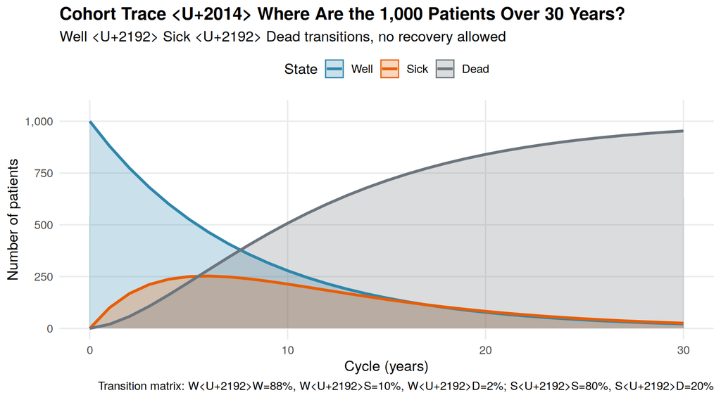

```r
# Reshape for ggplot
trace_df <- as.data.frame(trace) %>%
  mutate(Cycle = 0:n_cycles) %>%
  pivot_longer(c(Well, Sick, Dead), names_to = "State", values_to = "N") %>%
  mutate(State = factor(State, levels = c("Well","Sick","Dead")))

ggplot(trace_df, aes(x = Cycle, y = N, colour = State, fill = State)) +
  geom_area(alpha = 0.25, position = "identity") +
  geom_line(linewidth = 1.2) +
  scale_colour_manual(values = c(Well = col_well, Sick = col_sick, Dead = col_dead)) +
  scale_fill_manual(  values = c(Well = col_well, Sick = col_sick, Dead = col_dead)) +
  scale_y_continuous(labels = comma, limits = c(0, 1050)) +
  labs(title    = "Cohort Trace — Where Are the 1,000 Patients Over 30 Years?",
       subtitle = "Well → Sick → Dead transitions, no recovery allowed",
       x = "Cycle (years)", y = "Number of patients",
       colour = "State", fill = "State",
       caption = "Transition matrix: W→W=88%, W→S=10%, W→D=2%; S→S=80%, S→D=20%") +
  theme_minimal(base_size = 13) +
  theme(legend.position = "top",
        plot.title    = element_text(face = "bold"),
        panel.grid.minor = element_blank())
```

## 2.4 Proportions Over Time

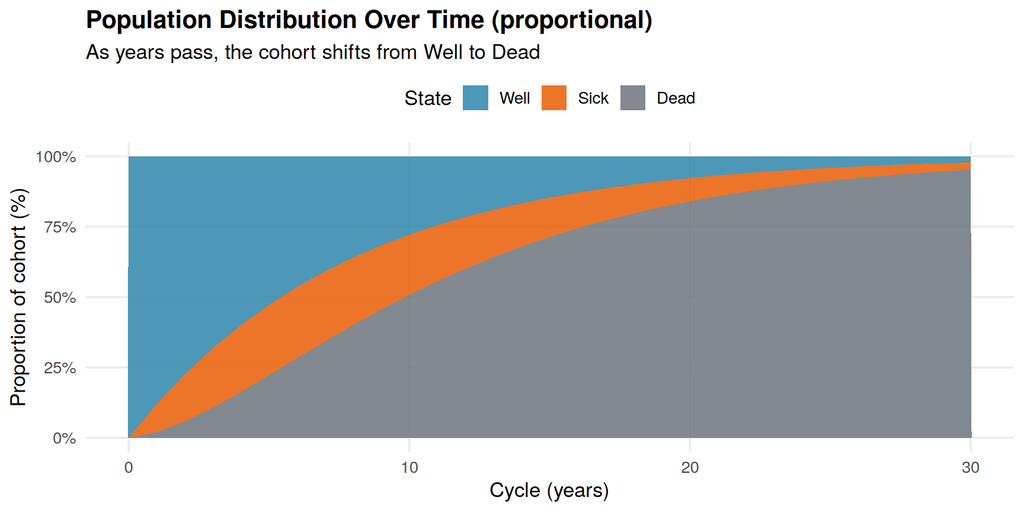

```r
trace_df %>%
  group_by(Cycle) %>%
  mutate(Prop = N / sum(N) * 100) %>%
  ggplot(aes(x = Cycle, y = Prop, fill = State)) +
  geom_area(alpha = 0.85) +
  scale_fill_manual(values = c(Well = col_well, Sick = col_sick, Dead = col_dead)) +
  scale_y_continuous(labels = function(x) paste0(x, "%")) +
  labs(title    = "Population Distribution Over Time (proportional)",
       subtitle = "As years pass, the cohort shifts from Well to Dead",
       x = "Cycle (years)", y = "Proportion of cohort (%)") +
  theme_minimal(base_size = 13) +
  theme(legend.position = "top", plot.title = element_text(face = "bold"),
        panel.grid.minor = element_blank())
```

# 3 Part 3 — The Mathematics: Why Matrices?

## 3.1 The Transition Matrix as a “Rule Book”

```r
# Display the matrix clearly
print(P)
```

```
##      Well Sick Dead
## Well 0.88  0.1 0.02
## Sick 0.00  0.8 0.20
## Dead 0.00  0.0 1.00
```

```r
cat("\nVerification: Row sums =", rowSums(P), "\n")
```

```
##
## Verification: Row sums = 1 1 1
```

**The key formula:**

$$\boxed{S_{t+1} = S_t \times
P}$$

where $S_t$ = population row vector at cycle $t$, and $P$ = transition matrix.

## 3.2 Manual Step-by-Step for Cycle 1

```r
# Step-by-step Cycle 1
cat("=== Starting Population ===\n")
```

```
## === Starting Population ===
```

```r
print(state_0)
```

```
## Well Sick Dead
## 1000    0    0
```

```r
cat("\n=== Matrix Multiplication: [1000, 0, 0] x P ===\n")
```

```
##
## === Matrix Multiplication: [1000, 0, 0] x P ===
```

```r
new_well  <- state_0["Well"] * P["Well","Well"]  + state_0["Sick"] * P["Sick","Well"]  + state_0["Dead"] * P["Dead","Well"]
new_sick  <- state_0["Well"] * P["Well","Sick"]  + state_0["Sick"] * P["Sick","Sick"]  + state_0["Dead"] * P["Dead","Sick"]
new_dead  <- state_0["Well"] * P["Well","Dead"]  + state_0["Sick"] * P["Sick","Dead"]  + state_0["Dead"] * P["Dead","Dead"]

cat(sprintf("  New Well = 1000 x 0.88 + 0 x 0 + 0 x 0 = %.0f\n", new_well))
```

```
##   New Well = 1000 x 0.88 + 0 x 0 + 0 x 0 = 880
```

```r
cat(sprintf("  New Sick = 1000 x 0.10 + 0 x 0.80 + 0 x 0 = %.0f\n", new_sick))
```

```
##   New Sick = 1000 x 0.10 + 0 x 0.80 + 0 x 0 = 100
```

```r
cat(sprintf("  New Dead = 1000 x 0.02 + 0 x 0.20 + 0 x 1 = %.0f\n", new_dead))
```

```
##   New Dead = 1000 x 0.02 + 0 x 0.20 + 0 x 1 = 20
```

```r
cat("\n=== Result After Cycle 1 ===\n")
```

```
##
## === Result After Cycle 1 ===
```

```r
state_1 <- state_0 %*% P
print(state_1)
```

```
##      Well Sick Dead
## [1,]  880  100   20
```

## 3.3 Two-Year Pathway Demonstration

```r
# All pathways to reach SICK after 2 cycles, starting from WELL
cat("=== Pathways to be SICK after 2 cycles (starting from Well) ===\n\n")
```

```
## === Pathways to be SICK after 2 cycles (starting from Well) ===
```

```r
path1 <- P["Well","Sick"] * P["Sick","Sick"]   # Well->Sick->Sick
path2 <- P["Well","Well"] * P["Well","Sick"]   # Well->Well->Sick

cat(sprintf("Path 1: Well -> Sick -> Sick = %.2f x %.2f = %.4f (%.1f%%)\n",
            P["Well","Sick"], P["Sick","Sick"], path1, path1*100))
```

```
## Path 1: Well -> Sick -> Sick = 0.10 x 0.80 = 0.0800 (8.0%)
```

```r
cat(sprintf("Path 2: Well -> Well -> Sick = %.2f x %.2f = %.4f (%.1f%%)\n",
            P["Well","Well"], P["Well","Sick"], path2, path2*100))
```

```
## Path 2: Well -> Well -> Sick = 0.88 x 0.10 = 0.0880 (8.8%)
```

```r
cat(sprintf("\nTotal probability of being Sick after 2 cycles = %.4f (%.1f%%)\n",
            path1 + path2, (path1+path2)*100))
```

```
##
## Total probability of being Sick after 2 cycles = 0.1680 (16.8%)
```

```r
# Confirm with matrix-squared
P2 <- P %*% P
cat(sprintf("\nConfirmed by P^2[Well, Sick] = %.4f (%.1f%%)\n",
            P2["Well","Sick"], P2["Well","Sick"]*100))
```

```
##
## Confirmed by P^2[Well, Sick] = 0.1680 (16.8%)
```

> **This is the beauty of matrix multiplication:**  
> It automatically sums all possible pathways without you having to enumerate them manually.

# 4 Part 4 — QALYs and Costs

## 4.1 Calculating QALYs Per Cycle

$$\text{QALYs at cycle }t = N_{Well,t}
\times 0.9 + N_{Sick,t} \times 0.6 + N_{Dead,t} \times 0$$

```r
# ── Compute QALYs and costs for every cycle ──────────────────────────────────
discount_rate <- 0.03   # 3% annual discount

results <- as.data.frame(trace) %>%
  mutate(
    Cycle       = 0:n_cycles,
    QALYs       = Well * utilities["Well"] + Sick * utilities["Sick"] + Dead * utilities["Dead"],
    Costs       = Well * costs["Well"]     + Sick * costs["Sick"]     + Dead * costs["Dead"],
    # Discount factor (cycle 0 = no discount)
    DiscFactor  = 1 / (1 + discount_rate)^Cycle,
    QALYs_disc  = QALYs * DiscFactor,
    Costs_disc  = Costs  * DiscFactor
  )

# Show first 6 rows
results %>%
  select(Cycle, Well, Sick, Dead, QALYs, Costs, DiscFactor, QALYs_disc, Costs_disc) %>%
  head(7) %>%
  kable(digits = c(0,1,1,1,1,0,4,1,0),
        caption = "Cohort Trace with QALYs, Costs and Discounting") %>%
  kable_styling(bootstrap_options = c("striped","hover","condensed"), full_width = FALSE,
                font_size = 12)
```

Cohort Trace with QALYs, Costs and Discounting

|  | Cycle | Well | Sick | Dead | QALYs | Costs | DiscFactor | QALYs_disc | Costs_disc |
| --- | --- | --- | --- | --- | --- | --- | --- | --- | --- |
| Cycle 0 | 0 | 1000.0 | 0.0 | 0.0 | 900.0 | 5000000 | 1.0000 | 900.0 | 5000000 |
| Cycle 1 | 1 | 880.0 | 100.0 | 20.0 | 852.0 | 7400000 | 0.9709 | 827.2 | 7184466 |
| Cycle 2 | 2 | 774.4 | 168.0 | 57.6 | 797.8 | 8912000 | 0.9426 | 752.0 | 8400415 |
| Cycle 3 | 3 | 681.5 | 211.8 | 106.7 | 740.4 | 9762560 | 0.9151 | 677.6 | 8934125 |
| Cycle 4 | 4 | 599.7 | 237.6 | 162.7 | 682.3 | 10127053 | 0.8885 | 606.2 | 8997755 |
| Cycle 5 | 5 | 527.7 | 250.1 | 222.2 | 625.0 | 10140606 | 0.8626 | 539.1 | 8747376 |
| Cycle 6 | 6 | 464.4 | 252.8 | 282.8 | 569.7 | 9906774 | 0.8375 | 477.1 | 8296767 |